# The Eigenvalue Problem and Solving Linear Systems

MATH 341 — Notes 10

University of Scranton

2026-10-31

# Goals

## What We Will Cover

1. **Exponential ansatz** $\mathbf{x} = \mathbf{v}e^{\lambda t}$ — why exponentials work for $\mathbf{x}' = A\mathbf{x}$
2. **Eigenvalues and eigenvectors** — solving $A\mathbf{v} = \lambda\mathbf{v}$ via the characteristic equation
3. **Real unequal eigenvalues** — saddle points and nodes; linear orbits and separatrices
4. **Complex eigenvalues** — spirals and centers via Euler’s formula
5. **Repeated eigenvalues** — star nodes and deficient (degenerate) nodes; generalized eigenvectors
6. **Phase plane** classification and stability for each case

**Note**

**Sections 4.3 and 4.4** of (Logan 2015).

**Tip**

New vocabulary: eigenvalue, eigenvector, eigenpair, characteristic equation, linear orbit, separatrix, saddle, node, spiral, center, deficient matrix, generalized eigenvector.

# Section 4.3

## The Eigenvalue Problem

## Why Exponentials?

We want to solve $\mathbf{x}' = A\mathbf{x}$, where $A$ is a constant $2\times 2$ matrix.

**Key observation:** for all terms to cancel when substituted into the ODE, the solution and its derivative must have the **same form**. Exponential functions satisfy this.

**Ansatz:** try $\mathbf{x} = \mathbf{v}e^{\lambda t}$, so $\mathbf{x}' = \lambda\mathbf{v}e^{\lambda t}$.

Substituting into $\mathbf{x}' = A\mathbf{x}$:

$$\lambda\mathbf{v}e^{\lambda t} = A\mathbf{v}e^{\lambda t}.$$

Cancel $e^{\lambda t} \neq 0$:

$$\boxed{A\mathbf{v} = \lambda\mathbf{v}.} \tag{4.28}$$

We have converted a **differential equations problem** into an **algebraic problem**.

## Eigenvalues, Eigenvectors, Eigenpairs

**Remark 4.26**

A nonzero constant vector $\mathbf{v}$ is an **eigenvector** of $A$ if $A\mathbf{v} = \lambda\mathbf{v}$ for some scalar $\lambda$. The scalar $\lambda$ is an **eigenvalue** of $A$. The pair $\lambda,\,\mathbf{v}$ is an **eigenpair**.

**Every eigenpair of $A$ gives a solution $\mathbf{x}(t) = \mathbf{v}e^{\lambda t}$ of $\mathbf{x}' = A\mathbf{x}$.**

**Geometric picture:** $A$ transforms vectors to vectors. An eigenvector is a special vector that $A$ maps to a **scalar multiple of itself** — that multiple is the eigenvalue.

**Two facts:**

1. Any constant multiple of an eigenvector is again an eigenvector for the same eigenvalue — so eigenvectors are unique only up to a scalar multiple.
2. If $\lambda_1 \neq \lambda_2$, then $\mathbf{v}_1$ and $\mathbf{v}_2$ are **linearly independent**.

## Solving the Eigenvalue Problem

Rewrite $A\mathbf{v} = \lambda\mathbf{v}$ as the homogeneous system

$$(A - \lambda I)\mathbf{v} = \mathbf{0}. \tag{4.29}$$

Nontrivial solutions exist $\iff$ $\det(A - \lambda I) = 0$. For $A = \begin{pmatrix}a&b\\c&d\end{pmatrix}$:

$$\det\begin{pmatrix}a-\lambda & b \\ c & d-\lambda\end{pmatrix} = \lambda^2 - (a+d)\lambda + (ad-bc) = 0,$$

or more memorably:

$$\boxed{\lambda^2 - (\text{tr}\,A)\lambda + \det A = 0.} \tag{4.32}$$

This is the **characteristic equation** — a quadratic in $\lambda$.

**Algorithm**

1. **Solve** $\lambda^2 - (\text{tr}\,A)\lambda + \det A = 0$ for the eigenvalues.
2. **Substitute** each $\lambda$ into $(A-\lambda I)\mathbf{v}=\mathbf{0}$; only one equation is needed (the other is dependent).

## Example 4.27 — Finding Eigenpairs

$$A = \begin{pmatrix}1&1\\4&1\end{pmatrix}, \quad \text{tr}\,A=2, \quad \det A = -3.$$

**Characteristic equation:** $\lambda^2 - 2\lambda - 3 = (\lambda+1)(\lambda-3) = 0$.

Eigenvalues: $\lambda_1 = -1$, $\lambda_2 = 3$.

**For $\lambda_1 = -1$:** $(A+I)\mathbf{v}=\mathbf{0}$ gives $2v_1 + v_2 = 0$, so $\mathbf{v}_1 = (1,-2)^T$.

**For $\lambda_2 = 3$:** $(A-3I)\mathbf{v}=\mathbf{0}$ gives $-2v_1 + v_2 = 0$, so $\mathbf{v}_2 = (1,2)^T$.

$$\lambda_1=-1,\;\mathbf{v}_1=\begin{pmatrix}1\\-2\end{pmatrix} \qquad \lambda_2=3,\;\mathbf{v}_2=\begin{pmatrix}1\\2\end{pmatrix}.$$

```python
s = sym.Symbol('lambda')
A = sym.Matrix([[1,1],[4,1]])
display(Math(r"\text{Char. poly: }" + sym.latex(A.charpoly(s).as_expr())))
for val, mult, vecs in A.eigenvects():
    display(Math(rf"\lambda={val},\;\mathbf{{v}}={sym.latex(vecs[0])}"))
```

$\displaystyle \text{Char. poly: }\lambda^{2} - 2 \lambda - 3$

$\displaystyle \lambda=-1,\;\mathbf{v}=\left[\begin{matrix}- \frac{1}{2}\\1\end{matrix}\right]$

$\displaystyle \lambda=3,\;\mathbf{v}=\left[\begin{matrix}\frac{1}{2}\\1\end{matrix}\right]$

## Example 4.28 — Complex Eigenvalues

$$A = \begin{pmatrix}-2 & -3\\3 & -2\end{pmatrix}, \quad \text{tr}\,A=-4, \quad \det A = 13.$$

**Characteristic equation:** $\lambda^2 + 4\lambda + 13 = 0 \implies \lambda = -2 \pm 3i$.

**Eigenvector for $\lambda = -2+3i$:** system $(A-\lambda I)\mathbf{v}=\mathbf{0}$ gives

$$-3iv_1 - 3v_2 = 0 \implies v_2 = -iv_1.$$

Taking $v_2 = i \Rightarrow v_1 = -1$:

$$\mathbf{v}_1 = \begin{pmatrix}-1\\i\end{pmatrix}, \qquad \mathbf{v}_2 = \begin{pmatrix}-1\\-i\end{pmatrix} \text{ (conjugate)}. \;\square$$

**Tip**

Complex eigenpairs always come in conjugate pairs. We need only work with **one** — it generates both real solutions via Euler’s formula.

# Section 4.4

## Solving Linear Systems

## The Master Strategy

Each eigenpair $\lambda,\,\mathbf{v}$ gives a solution $\mathbf{x}(t) = \mathbf{v}e^{\lambda t}$.

The structure of the solution — and the **phase portrait** — depends entirely on the nature of the eigenvalues:

| Eigenvalue type | Phase portrait | Stability |
| --- | --- | --- |
| Real, opposite signs | Saddle | Unstable |
| Both negative, unequal | Stable node | Asymp. stable |
| Both positive, unequal | Unstable node | Unstable |
| Complex, $\text{Re}(\lambda)<0$ | Stable spiral | Asymp. stable |
| Complex, $\text{Re}(\lambda)>0$ | Unstable spiral | Unstable |
| Purely imaginary | Center | Stable |
| Repeated, non-deficient | Star node | Stable ($\lambda<0$) |
| Repeated, deficient | Degenerate node | Stable ($\lambda<0$) |

# Real Unequal Eigenvalues

## General Solution and Linear Orbits

If $\lambda_1 \neq \lambda_2$ are real with eigenvectors $\mathbf{v}_1,\,\mathbf{v}_2$ (independent), the general solution is

$$\mathbf{x}(t) = c_1\mathbf{v}_1 e^{\lambda_1 t} + c_2\mathbf{v}_2 e^{\lambda_2 t}. \tag{4.34}$$

**Linear Orbits (Remark 4.31)**

The solution $\mathbf{x}(t) = \mathbf{v}e^{\lambda t}$ is called a **linear orbit** — a ray along the direction of $\mathbf{v}$ in the phase plane:

- $\lambda < 0$: ray **enters** the origin as $t \to +\infty$
- $\lambda > 0$: ray **exits** the origin as $t \to +\infty$

Every eigenpair gives **two opposing rays** (for $\pm\mathbf{v}$).

## Saddle Points — Opposite Signs

When $\lambda_1 < 0 < \lambda_2$:

- Linear orbits along $\mathbf{v}_1$: **approach** origin ($\lambda_1 < 0$)
- Linear orbits along $\mathbf{v}_2$: **leave** origin ($\lambda_2 > 0$)
- All other orbits: **hyperbolic** curves

The linear orbits are called **separatrices** — they separate different types of orbital behavior.

**The origin is a saddle point — always unstable.**

As $t\to+\infty$: $e^{\lambda_1 t}\to 0$, so all orbits approach the direction of $\mathbf{v}_2$.

As $t\to-\infty$: $e^{\lambda_2 t}\to 0$, so all orbits approach the direction of $\mathbf{v}_1$.

## Example 4.30 — Saddle Point

$$\mathbf{x}' = \begin{pmatrix}1&1\\4&1\end{pmatrix}\mathbf{x}, \quad \lambda_1=-1,\;\mathbf{v}_1=\begin{pmatrix}1\\-2\end{pmatrix},\quad \lambda_2=3,\;\mathbf{v}_2=\begin{pmatrix}1\\2\end{pmatrix}.$$

$$\mathbf{x}(t) = c_1\begin{pmatrix}1\\-2\end{pmatrix}e^{-t} + c_2\begin{pmatrix}1\\2\end{pmatrix}e^{3t}. \tag{4.35}$$

[figure not shown]

Figure 1

## Stable and Unstable Nodes

**Both $\lambda_1 < \lambda_2 < 0$ (stable node):**

- All orbits enter origin as $t\to+\infty$
- Orbits tangent to **slow** eigendirection ($\mathbf{v}_2$, eigenvalue closer to 0) as $t\to+\infty$
- Orbits parallel to **fast** eigendirection ($\mathbf{v}_1$) as $t\to-\infty$

**Both $0 < \lambda_1 < \lambda_2$ (unstable node):**

- Same picture with arrows reversed — orbits exit origin
- Tangent to slow direction as $t\to-\infty$

**$\det A = 0$, $\lambda=0$:**

- Non-isolated equilibria along entire line $ax+by=0$
- Other orbits are parallel straight lines $y=mx+C$

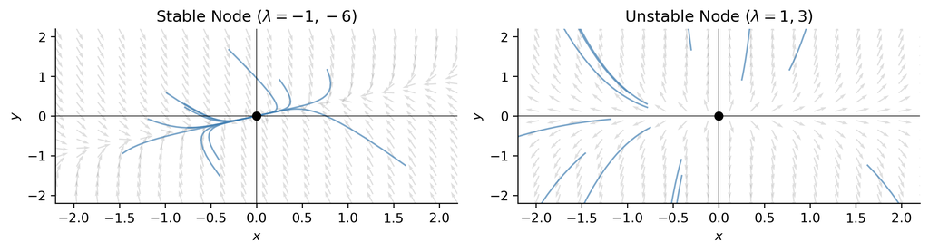

Figure 2

# Complex Eigenvalues

## From Complex Eigenpairs to Real Solutions

If $\lambda = a \pm bi$ (complex), write the eigenvector as $\mathbf{v} = \mathbf{w} \pm i\mathbf{z}$.

Expand one complex solution via **Euler’s formula** $e^{ibt} = \cos bt + i\sin bt$:

$$(\mathbf{w}+i\mathbf{z})e^{(a+bi)t} = e^{at}(\mathbf{w}\cos bt - \mathbf{z}\sin bt) + i\,e^{at}(\mathbf{w}\sin bt + \mathbf{z}\cos bt).$$

Real and imaginary parts are each **real, independent solutions**:

$$\mathbf{x}_1(t) = e^{at}(\mathbf{w}\cos bt - \mathbf{z}\sin bt), \quad
\mathbf{x}_2(t) = e^{at}(\mathbf{w}\sin bt + \mathbf{z}\cos bt).$$

**General solution:**

$$\mathbf{x}(t) = c_1\mathbf{x}_1(t) + c_2\mathbf{x}_2(t). \tag{4.38}$$

## Orbital Behavior: Spirals and Centers

The factor $e^{at}$ controls amplitude; the trig terms produce rotation:

| Real part $a$ | Behavior | Phase portrait |
| --- | --- | --- |
| $a < 0$ | Amplitude decays | **Stable spiral** (attractor) |
| $a > 0$ | Amplitude grows | **Unstable spiral** (repeller) |
| $a = 0$ | No amplitude change | **Stable center** — closed ellipses |

**Tip**

To determine the **direction of rotation** (CW or CCW), compute the direction vector $(x',y')$ at any convenient point and check the sign.

## Example 4.37 — Asymptotically Stable Spiral

$$\mathbf{x}' = \begin{pmatrix}-2&-3\\3&-2\end{pmatrix}\mathbf{x}, \quad \lambda=-2\pm 3i, \quad \mathbf{w}=\begin{pmatrix}-1\\0\end{pmatrix},\; \mathbf{z}=\begin{pmatrix}0\\1\end{pmatrix}.$$

Since $a = -2 < 0$: **asymptotically stable spiral**. At $(1,1)$: $(x',y')=(-5,1)$ — spirals are **counterclockwise**. $\square$

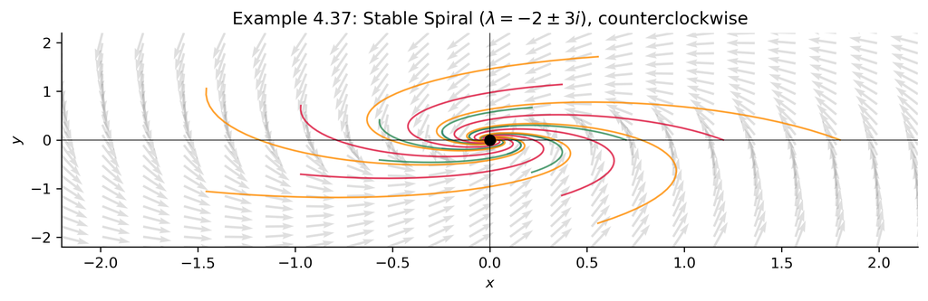

Figure 3

# Real Equal Eigenvalues

## Two Subcases

Suppose $\lambda_1 = \lambda_2 \equiv \lambda \neq 0$. There are two cases:

**Case 1 — Non-deficient:** $A$ has two independent eigenvectors $\mathbf{v}_1,\,\mathbf{v}_2$.

$$\mathbf{x}(t) = c_1\mathbf{v}_1 e^{\lambda t} + c_2\mathbf{v}_2 e^{\lambda t}.$$

Every direction through the origin is a linear orbit — a **star node**.

**Case 2 — Deficient:** $A$ has only **one** eigenvector $\mathbf{v}$.

$\mathbf{x}_1(t) = \mathbf{v}e^{\lambda t}$ is one solution. The second is

$$\mathbf{x}_2(t) = e^{\lambda t}(t\mathbf{v} + \mathbf{w}),$$

where $\mathbf{w}$ is a **generalized eigenvector** satisfying

$$(A-\lambda I)\mathbf{w} = \mathbf{v}. \tag{4.39}$$

General solution: $\mathbf{x}(t) = c_1\mathbf{v}e^{\lambda t} + c_2e^{\lambda t}(t\mathbf{v}+\mathbf{w})$.

## Deficient Case: Why $t\mathbf{v}e^{\lambda t}$ Alone Fails

**Intuition from Chapter 2:** for scalar equations with repeated roots, the second solution is $te^{\lambda t}$. For systems, the direct analog $t\mathbf{v}e^{\lambda t}$ does *not* work.

Try $\mathbf{x}_2 = e^{\lambda t}(t\mathbf{v} + \mathbf{w})$:

$$\mathbf{x}_2' = e^{\lambda t}\mathbf{v} + \lambda e^{\lambda t}(t\mathbf{v}+\mathbf{w}), \qquad A\mathbf{x}_2 = e^{\lambda t}A(t\mathbf{v}+\mathbf{w}).$$

Setting $\mathbf{x}_2' = A\mathbf{x}_2$ and using $A\mathbf{v} = \lambda\mathbf{v}$:

$$\mathbf{v} + \lambda\mathbf{w} = A\mathbf{w} \implies (A-\lambda I)\mathbf{w} = \mathbf{v}. \;\checkmark$$

This system always has solutions because $\det(A-\lambda I) = 0$. Choose any one solution $\mathbf{w}$ — it is called a **generalized eigenvector**.

## Example 4.39 — Deficient Matrix

$$\mathbf{x}' = \begin{pmatrix}2&1\\-1&4\end{pmatrix}\mathbf{x}, \quad \lambda=3,3, \quad \mathbf{v}=\begin{pmatrix}1\\1\end{pmatrix}.$$

**First solution:** $\mathbf{x}_1(t) = \begin{pmatrix}1\\1\end{pmatrix}e^{3t}$ (linear orbit along $y=x$).

**Find $\mathbf{w}$:** solve $(A-3I)\mathbf{w} = \mathbf{v}$:

$$\begin{pmatrix}-1&1\\-1&1\end{pmatrix}\mathbf{w} = \begin{pmatrix}1\\1\end{pmatrix} \implies -w_1+w_2=1.$$

Choose $\mathbf{w} = (0,1)^T$.

**Second solution:**

$$\mathbf{x}_2(t) = e^{3t}\!\left[\begin{pmatrix}1\\1\end{pmatrix}t+\begin{pmatrix}0\\1\end{pmatrix}\right] = \begin{pmatrix}te^{3t}\\(t+1)e^{3t}\end{pmatrix}.$$

**IVP $\mathbf{x}(0)=(1,0)^T$:** $c_1=1$, $c_2=-1$ gives $\mathbf{x}(t) = \begin{pmatrix}(1-t)e^{3t}\\-te^{3t}\end{pmatrix}$.

Unstable node ($\lambda>0$). $\square$

## Example 4.39 — Phase Portrait

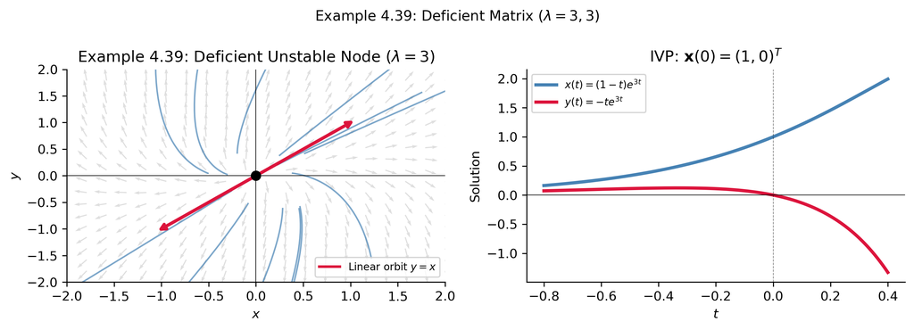

Figure 4

# Summary

## Key Takeaways

- The **eigenvalue ansatz** $\mathbf{x} = \mathbf{v}e^{\lambda t}$ converts $\mathbf{x}' = A\mathbf{x}$ into the algebraic problem $A\mathbf{v} = \lambda\mathbf{v}$. Every eigenpair gives a solution.
- Eigenvalues come from the **characteristic equation** $\lambda^2 - (\text{tr}\,A)\lambda + \det A = 0$; eigenvectors from solving $(A-\lambda I)\mathbf{v}=\mathbf{0}$.
- **Real unequal eigenvalues** give linear orbits (rays) and either a **saddle** (opposite signs) or a **node** (same sign). Orbits of a node enter/exit the origin tangent to the slow eigenvector.
- **Complex eigenvalues** $\lambda=a\pm bi$ give oscillatory solutions via Euler’s formula. The sign of $a$ determines whether orbits spiral in (**stable**), spiral out (**unstable**), or close (**center**).
- **Repeated eigenvalues** with two independent eigenvectors give a **star node**. If the matrix is **deficient** (one eigenvector), a **generalized eigenvector** $\mathbf{w}$ satisfying $(A-\lambda I)\mathbf{w}=\mathbf{v}$ is needed, giving the second solution $e^{\lambda t}(t\mathbf{v}+\mathbf{w})$ — a **degenerate node**.
- In all cases, stability is determined by the **sign of the real part of the eigenvalues**: negative real parts → stable; any positive real part → unstable; zero real part → inconclusive (or center).

**Tip**

**Looking Ahead:** This classification — based on $\text{tr}\,A$ and $\det A$ — is systematized in the trace-determinant plane in §4.5, giving a complete map of all possible phase portraits for linear systems.

**Note**

**Next:** Phase Plane Analysis — Logan §4.5.

## References

Logan, J David. 2015. *A First Course in Differential Equations, Third Edition*.